# Giro Velogames Daily Update

### Race Results - Stage 21

Many of you no doubt already know the result, but here’s the non-spoiler 5min highlight clip on Youtube:  
https://youtu.be/iBVVAbSllJk  
Although Time Trial specialist Tom Dumoulin was pipped by countryman Jos van Emden for victory in the final stage of the Giro D’Italia, the Dutchman was most interested in the finishing time of the little Columbian and wearer of the leaders’ Maglia Rosa, the last rider to finish. Big Tom need not be concerned as his time gap over Quintana was more than enough to secure his first Grand Tour win. Duloulin’s victory in the 100th edition of the Giro was historic for more than one reason, given it’s the first Grand Tour victory for a Dutch rider since Joop Zoetemelk won the 1980 Tour de France.  
Nairo Quintana limited his time loss to finish second overall with last year’s winner Vincenzo Nibali claiming the final spot on the podium.  
Results on cycling news:  
http://www.cyclingnews.com/giro-ditalia/stage-21/results/

| Stage Result |
| --- |

|  | # | Rider Name (Country) Team | Result |
| --- | --- | --- | --- |
| 2 | 1 | Jos van Emden (Ned) Team LottoNl-Jumbo | 0:33:08 |
| 3 | 2 | Tom Dumoulin (Ned) Team Sunweb | 0:00:15 |
| 4 | 3 | Manuel Quinziato (Ita) BMC Racing Team | 0:00:27 |
| 5 | 4 | Vasil Kiryienka (Blr) Team Sky | 0:00:31 |
| 6 | 5 | Joey Rosskopf (USA) BMC Racing Team | 0:00:35 |
| 7 | 6 | Jan Bárta (Cze) Bora-Hansgrohe | 0:00:39 |
| 8 | 7 | Georg Preidler (Aut) Team Sunweb | 0:00:51 |
| 9 | 8 | Bob Jungels (Lux) Quick-Step Floors | 0:00:54 |
| 10 | 9 | Jan Tratnik (Slo) CCC Sprandi Polkowice | 0:00:57 |
| 11 | 10 | Andrey Amador (CRc) Movistar Team | 0:01:02 |

### Velogames Results - Cunning Stunts - Final

It’s worth pointing out the method used by Velogames for calculating points after the final stage. Velogames awards points in the normal manner for Stage 21, but then awards points using an imaginary Stage 22 for Bonus Points based on rider finishing positions in accordance with the game rules:  
https://www.velogames.com/giro-ditalia/2017/scores.php

#### Highest Scoring Riders

##### for Stage 21, from our teams

The riders earning maximum points for Stage 21, and the teams that picked them were:

| rider | stage | Total | Selected by |
| --- | --- | --- | --- |
| Tom Dumoulin | 21 | 146 | Cooper`s Crankers |
| Vasil Kiryienka | 21 | 90 | Fly Guys |
| Georg Preidler | 21 | 60 | Brake Rub Regression |
| Vincenzo Nibali | 21 | 35 | Fly Guys,Cooper`s Crankers,Stinkys Strokers |
| Nairo Quintana | 21 | 25 | Bad Hombres,The Bandits,Brake Rub Regression |
| Marcin Bialoblocki | 21 | 25 | Stinkys Strokers |
| Thibaut Pinot | 21 | 18 | Bad Hombres,Fly Guys,Cooper`s Crankers |
| Ilnur Zakarin | 21 | 17 | Bad Hombres,Fly Guys,The Bandits,Stinkys Strokers |
| Domenico Pozzovivo | 21 | 15 | Brake Rub Regression |
| Mikel Landa | 21 | 14 | Bad Hombres |

#### Highest Scoring Riders

##### for Stage 22, from our teams

The riders earning maximum points from the Bonus Points on offer (Stage 22), and the teams that picked them were:

| rider | stage | Total | Selected by |
| --- | --- | --- | --- |
| Tom Dumoulin | 22 | 545 | Cooper`s Crankers |
| Nairo Quintana | 22 | 490 | Bad Hombres,The Bandits,Brake Rub Regression |
| Vincenzo Nibali | 22 | 360 | Fly Guys,Cooper`s Crankers,Stinkys Strokers |
| Thibaut Pinot | 22 | 325 | Bad Hombres,Fly Guys,Cooper`s Crankers |
| Ilnur Zakarin | 22 | 290 | Bad Hombres,Fly Guys,The Bandits,Stinkys Strokers |
| Domenico Pozzovivo | 22 | 260 | Brake Rub Regression |
| Bauke Mollema | 22 | 200 | The Bandits |
| Mikel Landa | 22 | 170 | Bad Hombres |
| Adam Yates | 22 | 160 | Fly Guys,Cooper`s Crankers,The Bandits,Stinkys Strokers,Brake Rub Regression |
| Sebastien Reichenbach | 22 | 110 | The Bandits |

The chart below demonstrates what a difference Tom Dumoulin made in the Velogames comp. Whilst Nario and Vincenzo also earnt a stack of points for their teams, their relative cost made them much poorer value. Bobby Jengels stands out as being excellent value as was Pozzovivo.

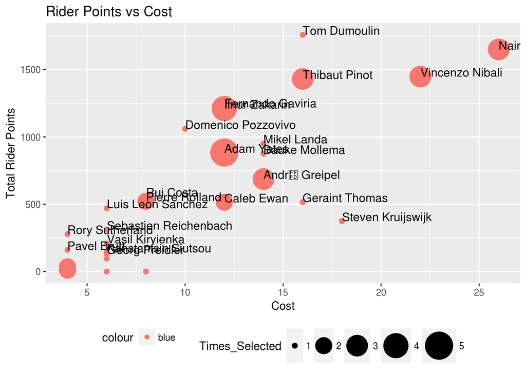

#### Top scoring teams for stage

Points from the ITT:

So Ben Neal cleaned up stage 21.

| team | directeur | Stage_Points |
| --- | --- | --- |
| Cooper`s Crankers | Ben Neal | 213 |
| Fly Guys | Stew Ralph | 178 |
| Brake Rub Regression | Simon Lyons | 112 |
| Stinkys Strokers | Lee Taylor | 89 |
| Bad Hombres | edmund g | 86 |
| The Bandits | Brendan Smith | 84 |

Bonus Points (Stage 22):

| team | directeur | Stage_Points |
| --- | --- | --- |
| Cooper`s Crankers | Ben Neal | 1480 |
| Bad Hombres | edmund g | 1465 |
| The Bandits | Brendan Smith | 1350 |
| Fly Guys | Stew Ralph | 1235 |
| Brake Rub Regression | Simon Lyons | 960 |
| Stinkys Strokers | Lee Taylor | 830 |

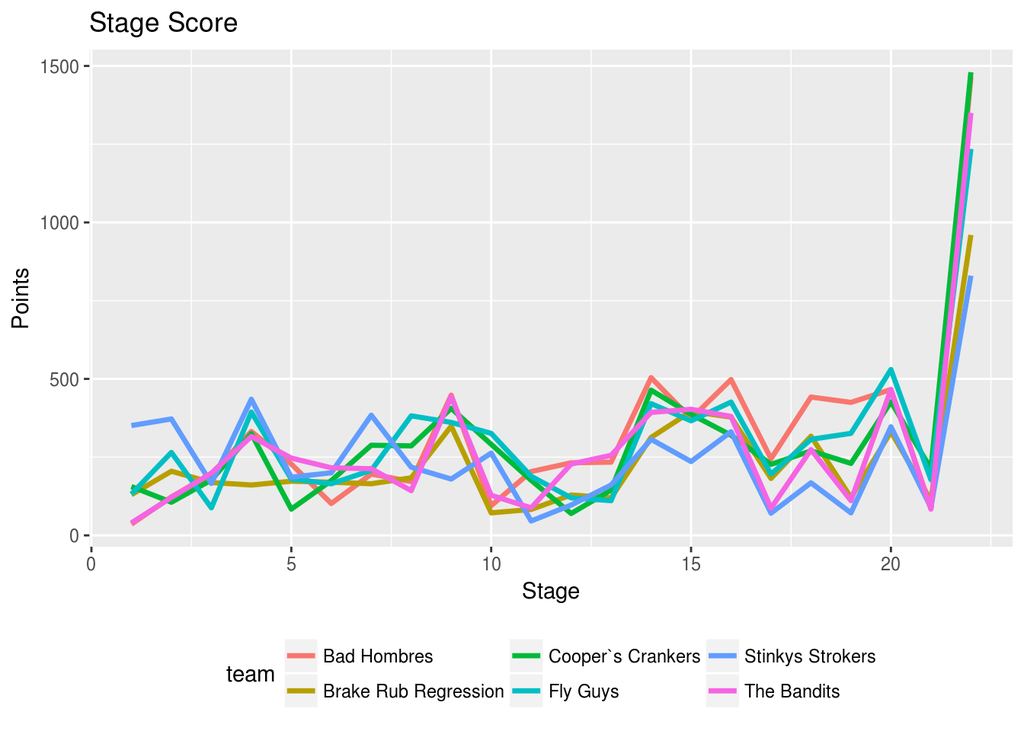

The final overall results after 21 stages is:

| Team | Total |
| --- | --- |
| Fly Guys | 5671 |
| Bad Hombres | 5637 |
| Cooper`s Crankers | 5223 |
| The Bandits | 4836 |
| Stinkys Strokers | 4680 |
| Brake Rub Regression | 4260 |

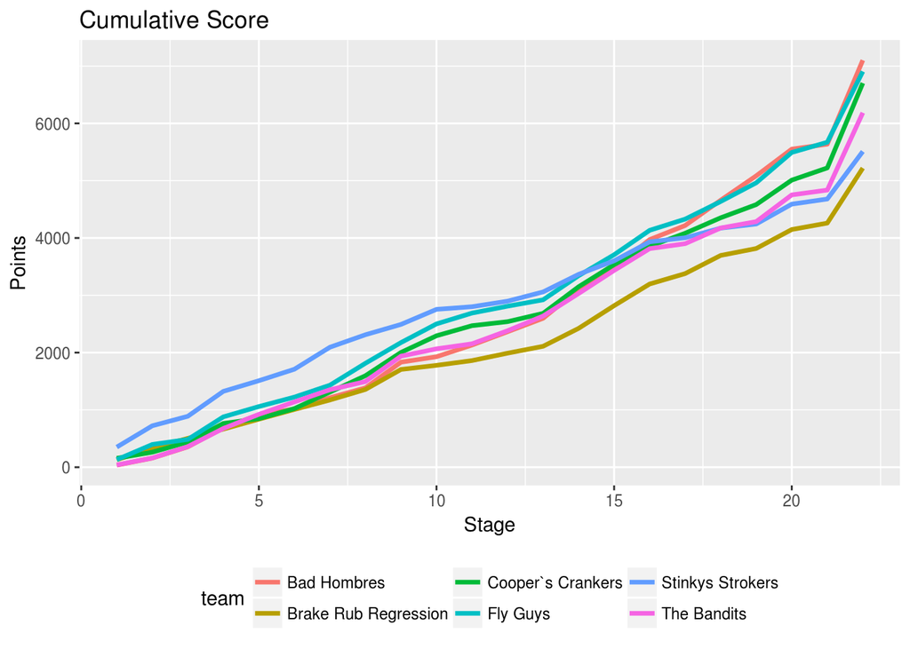

#### Inside Look

Here’s a look inside the teams taking top spots on the Velogames GC podium for this 100th edition of the Giro.

Rider Scores - Top Teams

| Team | Rider | Rider Total |
| --- | --- | --- |
| Bad Hombres | Nairo Quintana | 1650 |
| Bad Hombres | Thibaut Pinot | 1431 |
| Bad Hombres | Fernando Gaviria | 1219 |
| Cooper`s Crankers | Tom Dumoulin | 1758 |
| Cooper`s Crankers | Vincenzo Nibali | 1448 |
| Cooper`s Crankers | Thibaut Pinot | 1431 |
| Fly Guys | Vincenzo Nibali | 1448 |
| Fly Guys | Thibaut Pinot | 1431 |
| Fly Guys | Ilnur Zakarin | 1211 |